# Домашнее задание №3

Агалян Роберт БПТ214

## Введение

В нашем мини-исследовании будем использовать датафрейм содержащий результаты психолингвистического исследования, посвященного узнаваемости слов, в такого рода исследованиях участникам эксперимента предлагают определить, является ли слово, которое они видят на экране, реально существующим в языке или нет. Мы попытаемся проверить влияет ли длина слова, богатство морфологической семьи слова (как много однокоренных слов с разной частью речи), часть речи и количество синонимов у искомого слова на время, затраченное на узнавание слова (с момента появления слова на экране до нажатия кнопки, реальное слово или нет). В ходе работы попытемся проверить следующие гипотезы: 1. Чем короче слово, тем легче узнать, реальное оно или нет. 2. Чем богаче морфологическая семья слова, тем легче узнать, реальное оно или нет. 3. Определить реальность слова-существительного, сложнее чем глагола. 4. Чем больше количество синонимов, тем легче узнать, реальное оно или нет.

## Построение и запуск модели

```r
df <- read.csv("english.csv")
fit1 <- lm(RTlexdec ~ LengthInLetters + FamilySize + WordCategory + NumberSimplexSynsets, data = df)
summary(fit1)
```

```
##
## Call:
## lm(formula = RTlexdec ~ LengthInLetters + FamilySize + WordCategory +
##     NumberSimplexSynsets, data = df)
##
## Residuals:
##     Min      1Q  Median      3Q     Max
## -268.92  -82.26   -8.99   69.91  547.66
##
## Coefficients:
##                      Estimate Std. Error t value Pr(>|t|)
## (Intercept)           811.030      9.612  84.377   <2e-16 ***
## LengthInLetters         1.995      1.901   1.049    0.294
## FamilySize            -35.042      2.450 -14.304   <2e-16 ***
## WordCategoryV          -1.348      3.449  -0.391    0.696
## NumberSimplexSynsets  -27.665      3.071  -9.010   <2e-16 ***
## ---
## Signif. codes:  0 '***' 0.001 '**' 0.01 '*' 0.05 '.' 0.1 ' ' 1
##
## Residual standard error: 106.7 on 4563 degrees of freedom
## Multiple R-squared:  0.1379, Adjusted R-squared:  0.1372
## F-statistic: 182.5 on 4 and 4563 DF,  p-value: < 2.2e-16
```

Проинтепретируем коэффициенты. *Intercept.* Если все независимые переменные равны нулю, и слово - существительное, то среднее время, затраченное на узнавание слова составит 811.030 мс, но ситуация неправдоподобна, потому что в слове не может не быть ни одной буквы.  
*LengthInLetters.* При прочих равных, то есть если мы будем сравнивать время узнавания слов, которые отличаются только длиной, то на слова, которые длиннее на одну букву, будет потрачено в среднем на 1.995 мс больше времени.  
*FamilySize.* При прочих равных, то есть если мы будем сравнивать время узнавания слов, которые отличаются только богатством морфологической семьи (количеством однокоренных слов), то слова, у которых на одно однокоренное слово больше, будут узнаваться в среднем на 35.042 мс быстрее.  
*WordCategoryV.* При прочих равных, то есть если мы будем сравнивать время узнавания слов, отличающихся только частью речи, время, затраченное на узнавание глагола будет в среднем на 1.348 мс меньше, чем на существительное.  
*NumberSimplexSynsets.* При прочих равных, то есть если мы будем сравнивать время узнавания слов, отличающихся только количеством синонимов, то слова, у которых на 1 синоним больше, будут узнаны в среднем на 27.665 мс быстрее.

Если посмотреть на p-value в выдаче, то можем сказать, что оценки коэффициентов при переменной **FamilySize** и **NumberSimplexSynsets** статистически значимы на 0.1% уровне значимости. Остальные оценки оказались незначимыми. Также у нашей модели небольшая предсказательная сила: коэффициент детерминации $R^{2} = 13,79\%$. Следовательно, наша модель объясняет 13,79% изменчивости зависимой переменной.

## Проверка условий Гаусса-Маркова

### Условие о равенстве математического ожидания остатков нулю.

Для начала добавим в датафрейм столбцы с предсказанными значениями и остатками модели и загрузим библиотеку **ggplot2**, она пригодится нам для визуализации:

```r
df$res <- fit1$residuals
df$fitted <- fit1$fitted.values
library(ggplot2)
```

Теперь выведем описательные статистики для остатков:

```r
summary(df$res)
```

```
##     Min.  1st Qu.   Median     Mean  3rd Qu.     Max.
## -268.923  -82.257   -8.987    0.000   69.911  547.655
```

Как мы видим, среднее значени равно нулю, однако медианное совсем нет. Условие не выполняется, попытаемся убедиться в этом далее.

### Нормальность распределения остатков

Построим гистограмму по остаткам:

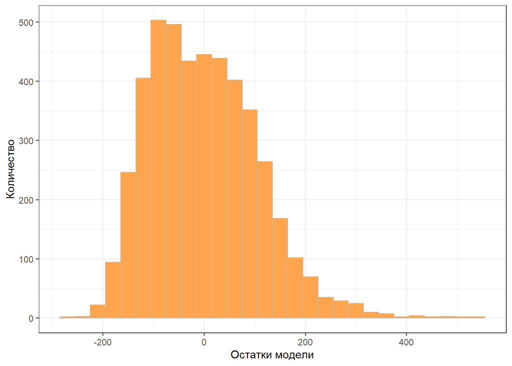

```r
ggplot(data = df, aes(x = res))+
  geom_histogram(fill = "tan1", color = "tan", binwidth = 30)+
  xlab("Остатки модели")+
  ylab("Количество")+
  theme_bw()
```

Для лучшего понимания ситуации построим Q-Q plot:

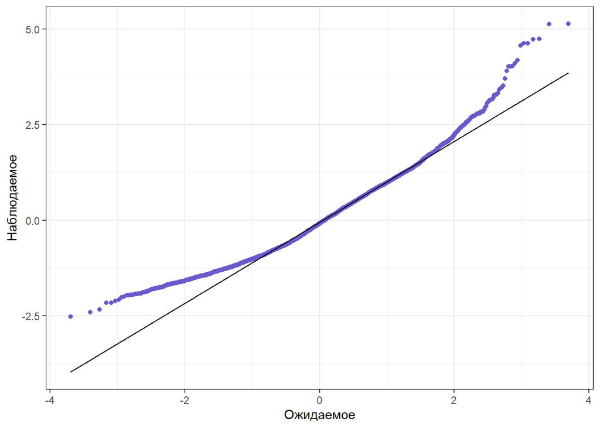

```r
ggplot(data = df, aes(sample = scale(res)))+
  stat_qq(color = "slateblue3")+
  stat_qq_line()+
  xlab("Ожидаемое")+
  ylab("Наблюдаемое")+
  theme_bw()
```

Судя по тому, что точки в начале и в конце графика отклоняются от линии, распределение не соответствует нормальному, примени критерий Шапиро-Уилка к нашим остаткам:

```r
shapiro.test(fit1$residuals)
```

```
##
##  Shapiro-Wilk normality test
##
## data:  fit1$residuals
## W = 0.97171, p-value < 2.2e-16
```

P-value мало, отклоняем нулевую гипотезу о нормальности распределения остатков. Условие не выполняется.

## Гомоскедастичность

Построим диаграмму рассеивания по предсказанным значениям модели и остаткам:

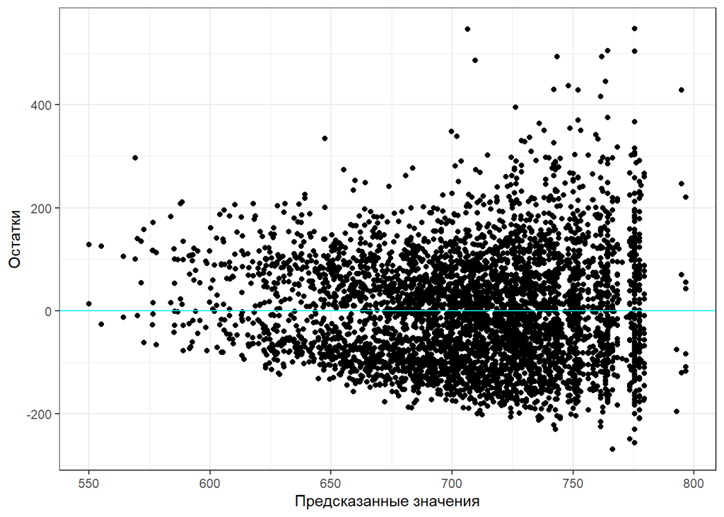

```r
ggplot(data = df, aes(x = fitted, y = res))+
  geom_point() + geom_hline(yintercept = 0, color = "cyan1")+
  xlab("Предсказанные значения")+
  ylab("Остатки")+
  theme_bw()
```

Ошибки остатков заметно больше в правой части диаграммы. Вероятна гетероскедастичность. Загрузим библиотеку **lmtest** для применения критейрия Бройша-Пагана к нашей модели: ##

```r
library(lmtest)
bptest(fit1)
```

```
##
##  studentized Breusch-Pagan test
##
## data:  fit1
## BP = 116.04, df = 4, p-value < 2.2e-16
```

P-value мало, отклоняем нулевую гипотезу о гомоскедастичности в пользу альтернативной. Условие не выполняется

## Отсутствие связей между остатками и предикторами

Для проверки этого условия нам понадобится построить диаграммы рассеивания для остатков и каждого предиктора. Начнём с длины слова - переменной **LengthInLetters**, визуализируем:

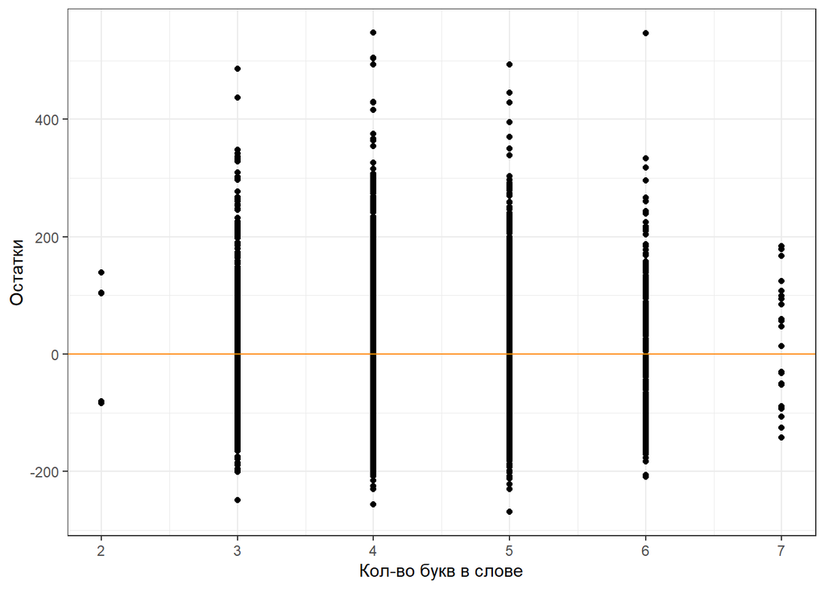

```r
ggplot(data = df, aes(x = LengthInLetters, y = res))+
  geom_point() + geom_hline(yintercept = 0, color = "darkorange")+
  ylab("Остатки")+
  xlab("Кол-во букв в слове")+
  theme_bw()
```

Как мы видим, в левой и правой частях графика остатки заметно меньше. Наблюадется связь между количеством слов и остатков.

Проверим с переменной **FamilySize**, построим диаграмму:

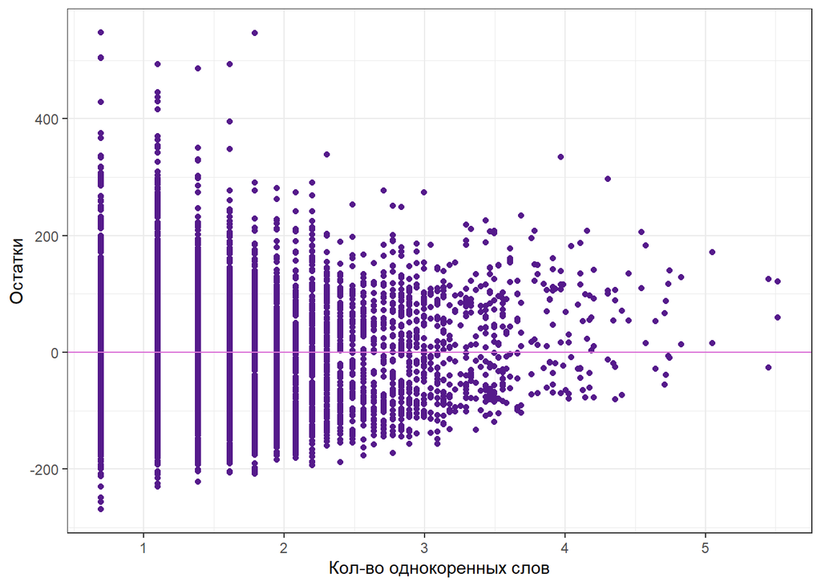

```r
ggplot(data = df, aes(x = FamilySize, y = res))+
  geom_point(color = "purple4")+
  geom_hline(yintercept = 0, color = "orchid")+
  ylab("Остатки")+
  xlab("Кол-во однокоренных слов")+
  theme_bw()
```

Весьма заметно, что ошибки меньше с ростом занчения переменной, то есть с ростом количества однокоренных слов.

Проверим связь с переменной **WordCategory**, то есть с частью речи, построим диаграмму:

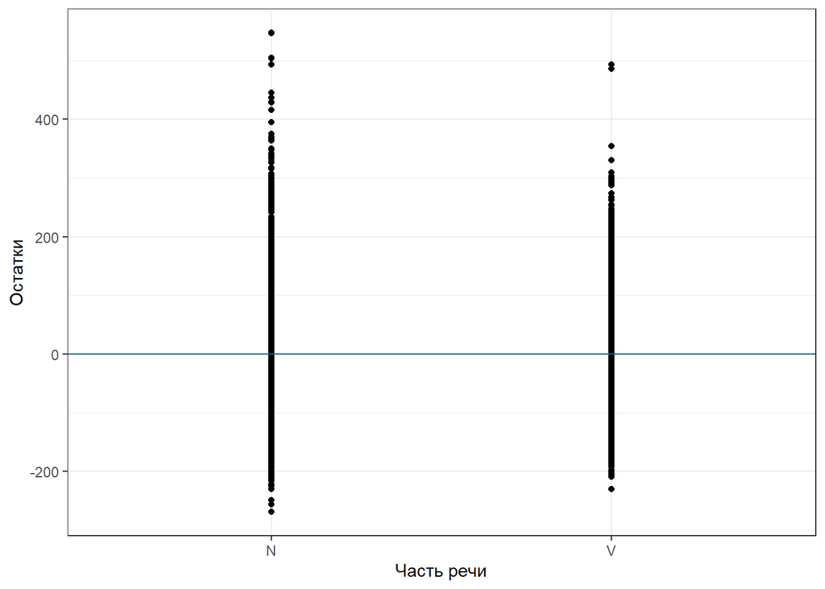

```r
ggplot(data = df, aes(x = WordCategory, y = res))+
  geom_point()+
  geom_hline(yintercept = 0, color = "deepskyblue4")+
  ylab("Остатки")+
  xlab("Часть речи")+
  theme_bw()
```

Проверим выполнения этого условия для переменной **NumberSimplexSynsets**, построим диаграмму для этого:

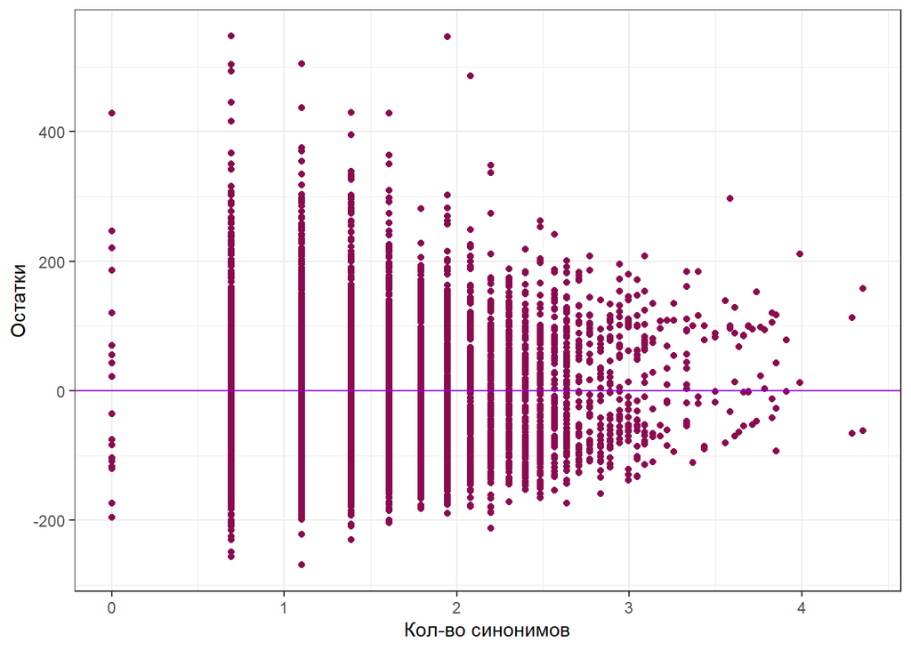

```r
ggplot(data = df, aes(x = NumberSimplexSynsets, y = res))+
  geom_point(color = "deeppink4")+
  geom_hline(yintercept = 0, color = "darkviolet")+
  ylab("Остатки")+
  xlab("Кол-во синонимов")+
  theme_bw()
```

Остатки становятся заметно меньше с увеличением числа синонимов, связь с предиктором есть.

## Наличие влиятельных наблюдений

Для проверки наличия влиятельных наблюдений построим соответствующую гистограмму:

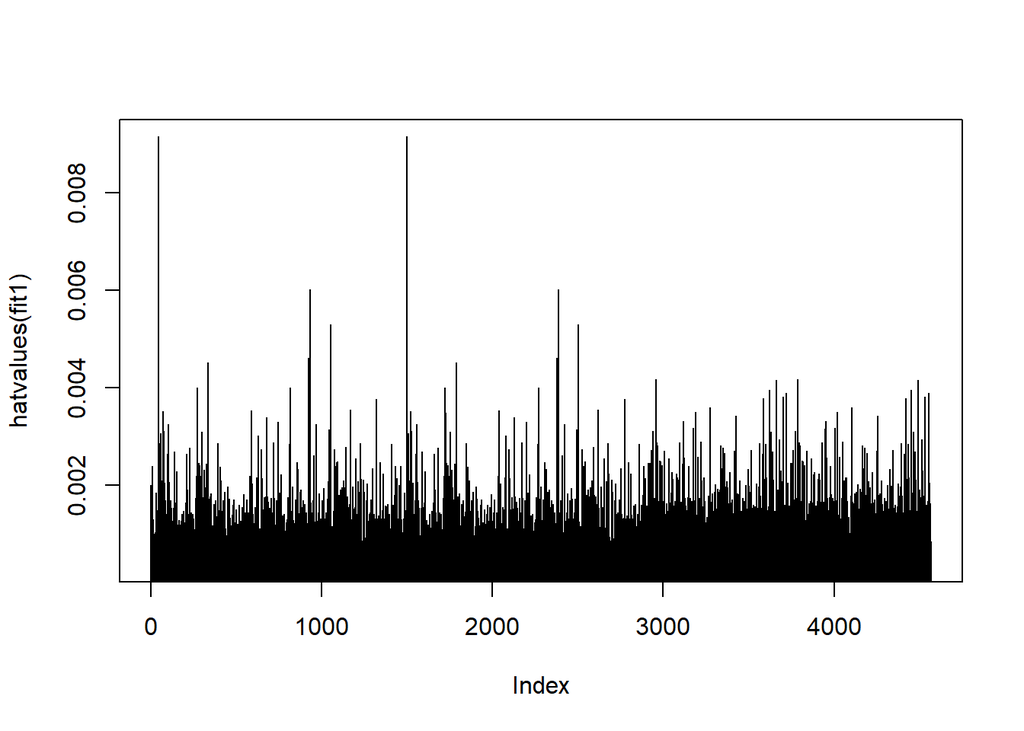

```r
plot(hatvalues(fit1), type = 'h')
```

Можем сказать, что влиятельные наблюдения отсутствуют.